# Visualisation-tp1 : Extension Data Science Studio

rchailan

Novembre 2018

### Introduction

Dans ce TP introductif vous allez vous servir de **Data Science Studio** comme outil d’aide au développement d’un projet de science des données. Entre autre, vous allez mettre en application vos acquis de visualisation des données au sein d’un tableau de bord.

Dans cette courte introduction vous allez :

- récupérer des données depuis un fichier en ligne,
- faire une simple modification sur ce fichier,
- construire un graphique à l’aide du moteur de visualisations intégré,
- reproduire votre graphique du TP ggplot sur ce jeu de donnée à l’intérieur d’une recette R,
- publier les 2 graphiques dans un rapport.

En bonus, vous allez réaliser très simplement un algorithme de clustering : *k-means*.

[figure not shown]

Objectif du TP

### Connexion

> Pensez bien que sur les machines de salle TP3/4, DSS est accessible par tous les utilisateurs. En utilisant le compte administrateur, quiconque pourra réutiliser / supprimer votre travail. Il s’agit donc uniquement d’un accès éducatif. Pour vos projets, demandez l’accès à votre compte sur le serveur IG.

### Étapes par étapes

#### Préparation données

1. Dans un premier temps récupérons les données. Ouvrez [ce lien](https://archive.ics.uci.edu/ml/machine-learning-databases/iris/iris.data) pour télécharger les données et chargez les en tant que fichier `.csv` dans votre nouveau projet. Une alternative est de les récupérer via un dataset distant : *Network/http*.
2. Lors du chargement des données, dans Format/Preview pensez à vérifier le format de la table que vous allez créer. Vous pouvez voir que les noms des colonnes ne sont pas renseignés. Rajoutez-les[^1], sans perdre de lignes.  
   Vous devriez avoir *151* données une fois le jeu de données créé (bouton create en haut à droite, après avoir donnée un nom à votre jeu de données). À l’aide de la barre verte en dessous du type sémantique auto-detecté par DSS (en bleu), vous pouvez vous rendre compte que la dernière ligne de votre jeu de donnée est vide.
3. Pour pallier à ce problème, créez une recette `Prepare`. Vous allez supprimer cette ligne. Il s’agit d’ajouter une *step* `Remove rows`. N’oubliez pas d’appuyer sur `Run` pour que le jeu de données préparé soit construit.

#### Data Viz

1. À ce stade, vous pouvez d’ores et déjà faire une première visualisation de vos données à l’aide de l’onglet `Charts`. Créez un nuage de points représentant les variables `petal_length` en fonction de `sepal_width`. Colorez les points à l’aide du `type`.

Publiez le résultat dans votre tableau de bord créé par défaut avec le bouton `Publish`. Revenez maintenant sur le *flow*, à partir du quel vous allez reproduire votre graphique sous `ggplot2`

2. Maintenant, créez un nouveau `repport Rmarkdown`. Un éditeur s’ouvre. Comme dans n’importe quelle recette de code ou notebooks (R, Python, SQL, …), nous pouvons développez dans le langage natif *de la recette*. Le code est ensuite interprété par le bon moteur – ici R et le package knitr pour un rapport Rmarkdown.
3. Reprenez votre travail sur ggplot et créez le code suffisant à la visualisation de votre graphique. Le début de la partie code commence par :

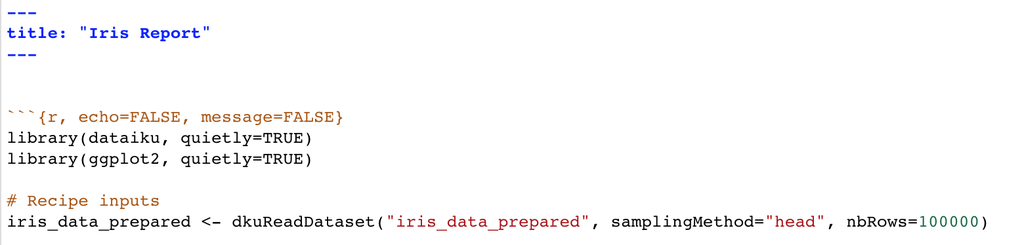

4. Publiez votre rapport dans votre tableau de bord par défaut.

#### Clustering

Créez un modèle de clustering sur les données iris préparées.

1. À partir de votre jeu de données, cliquez sur `Lab` > `Quick Model` > `Clustering` > `Quick Models` > `K-means`.
2. Avant d’entrainer le modèle, allez dans la partie `Design`. Désactiviez bien la variable `type` qui est la variable cible du modèle, celle que vous cherchez à reproduire. Ici on suppose qu’on ne la connait pas pour faire de l’apprentissage non supervisé.
3. Vous pouvez également définir le nombre de classes du modèle que vous voulez construire dans la partie `Modeling>Algorithms`.

[figure not shown]

Flow final

4. Entrainez puis déployez votre modèle. Quels sont les résultats ?
[^1]: *sepal_length*, *sepal_width*, *petal_length*, *petal_width*, *type*.